# MLM tutorial

bruce doré

September 23, 2017

```r
knitr::opts_chunk$set(echo = TRUE)
library(lme4)
```

```r
library(ggplot2)
library(gridExtra)
#FYI, coefplot2 is not on CRAN
#install.packages("coefplot2",repos="http://www.math.mcmaster.ca/bolker/R", type="source")
library(coefplot2)
```

## Multilevel models

**Definition:** Regression models in which coefficients (intercepts, slopes) are modeled as varying by “group” (in psychology, the “groups” are typically different people), according to a specific distribution (typically a normal distribution).

Multilevel modelling is an umbrella technique that includes single-level regression as a special case. Although I am not focusing on fundamentals of regression here, they still apply! Knowing them will go a long way toward helping you use these models effectively.

## why do we need MLM?

A standard rationale is that we need MLM to “account for nesting”. This is true but not very informative.

Here’s an alternative rationale: MLM provides a data-driven compromise between extremes of *complete pooling* of the data on one hand and *no pooling* of the data on the other.

What do I mean by *complete pooling*? I mean you delete the subject id column and then fit a single model to all of the data that estimates the population-level effect. There is complete pooling in the sense that we are fitting a single regression line that has data all the data points from every person pooled into it.

## complete pooling

To illustrate this, I’ll use the sleepstudy data included in the lme4 package. In this dataset, 18 people were subjected to sleep deprivation over 9 days and each person’s average reaction time on each day was recorded.

```r
head(sleepstudy)
```

```
##   Reaction Days Subject
## 1 249.5600    0     308
## 2 258.7047    1     308
## 3 250.8006    2     308
## 4 321.4398    3     308
## 5 356.8519    4     308
## 6 414.6901    5     308
```

```r
cp_model=lm(Reaction~1 + Days, data=sleepstudy)
#summary(cp_model) too much info!
round(coeftab(cp_model, clevel=.95, sd=F, p.val=F),1)
```

```
##             Estimate  2.5% 97.5%
## (Intercept)    251.4 238.4 264.4
## Days            10.5   8.0  12.9
```

This complete pooling model gives us an estimated intercept (predicted Reaction time at day=0) and a slope (relationship between Days of sleep deprivation and Reaction time), with 95% confidence intervals conveying the uncertainty in these estimates. However, we have assumed exactly zero variation from person to person in intercept and slope (i.e., all data points are pooled into a single line).

## no pooling

On the other hand, what do I mean by *no pooling*? I mean that each person gets their own separate regression line estimating their individual effect. There is no pooling of the data, in the sense that we are fitting totally separate regression lines for each person with no influence from the other people.

Here’s an example of this, using the same sleepstudy data

```r
#fit a diffent lm model to each person
np_models<-lapply(1:18, function(X){lm(Reaction ~ 1 + Days, data=subset(sleepstudy, Subject==unique(sleepstudy$Subject)[X]))})
#summary(np_models)[[1]] -- too much info!!
round(coeftab(np_models[[1]], clevel=.95, sd=F, p.val=F),1)
```

```
##             Estimate  2.5% 97.5%
## (Intercept)    244.2 189.2 299.2
## Days            21.8  11.5  32.1
```

I used lapply (similar to a for loop) above to fit 18 different linear regression models, one to each person in the data set. Then I summarized the first person’s model, getting an intercept and slope for just that person (subject 308).

Below I’ll use ggplot to make a graph illustrating the complete vs no pooling strategies.

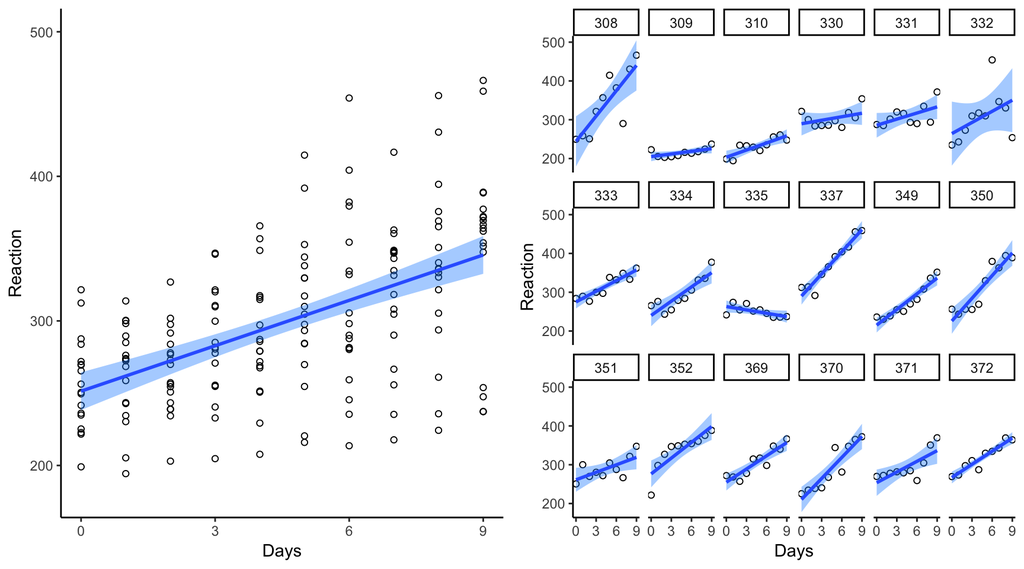

```r
p1 <- ggplot(sleepstudy, aes(x = Days, y = Reaction)) +
    geom_point(shape = 1) +
    geom_smooth(method = "lm", fill = "dodgerblue", level = .95) +
    scale_x_continuous(breaks = c(0, 3, 6, 9)) +
    coord_cartesian(ylim = c(180, 500)) + theme_classic()

p2 <- p1 + facet_wrap(~Subject, nrow = 3)
grid.arrange(p1, p2, ncol = 2)
```

The left panel represents a complete pooling regression, where information about subjects is discarded. The right panel shows no pooling regressions separately for each subject. This is very clean data (i.e., not noisy ) because 1) each observation of Reaction time is actually a mean of many observed trials, and 2) the data are completely balanced in that each subject has the same number of observations. It is clear from the right panel that there are strong relationships in each person, and there is clear variability in people’s mean levels of reaction time (some people are on average slow, others are on average fast) as well as how their reaction times change over time (most people get slower but note subject 335 who actually gets faster with each subsequent day of sleep deprivation).

## partial pooling

Although both the above approaches can be informative in some circumstances, they have serious limitations. Multilevel modelling provides a compromise between these two extremes – partial pooling of the data. This improves on the overly noisy no pooling estimates and the oversimplified complete pooling estimate.

What do I mean by partial pooling? I mean we can estimate the degree of person-to-person variance in our data, and use that to inform our person-specific and overall population estimates. With this procedure, we can get more accurate individual estimates by “borrowing information” from the group. We also get more accurate estimation of the overall population-level effect, by accounting for person to person variation. This is especially useful when there are very few observations per person, or different numbers of observations for different people.

**Varying Intercept and Varying Slope**

```r
#fit a multilevel model that partially pools data from different subjects
pp_model_vivs<-lmer(Reaction ~ 1+ Days + (1 + Days|Subject), data=sleepstudy)
round(coeftab(pp_model_vivs, clevel=.95, sd=F, p.val=F),1)
```

```
##             Estimate  2.5% 97.5%
## (Intercept)    251.4 238.0 264.8
## Days            10.5   7.4  13.5
```

```r
coef(pp_model_vivs)
```

```
## $Subject
##     (Intercept)       Days
## 308    253.6637 19.6662579
## 309    211.0065  1.8475828
## 310    212.4449  5.0184061
## 330    275.0956  5.6529547
## 331    273.6653  7.3973914
## 332    260.4446 10.1951153
## 333    268.2455 10.2436615
## 334    244.1725 11.5418620
## 335    251.0714 -0.2848731
## 337    286.2955 19.0955699
## 349    226.1950 11.6407002
## 350    238.3351 17.0814910
## 351    255.9829  7.4520288
## 352    272.2687 14.0032993
## 369    254.6806 11.3395026
## 370    225.7922 15.2897506
## 371    252.2121  9.4791309
## 372    263.7196 11.7513157
##
## attr(,"class")
## [1] "coef.mer"
```

Here we have fit a model that allows the intercept and slope to vary from person to person (like no pooling) and also generates overall population-level estimates for the intercept and slope (like complete pooling), but it does both of these things more accurately by combining all available information.

Compare the confidence interval from the complete pooling model to the one from the partial pooling model

```r
round(coeftab(cp_model, clevel=.95, sd=F, p.val=F),1)
```

```
##             Estimate  2.5% 97.5%
## (Intercept)    251.4 238.4 264.4
## Days            10.5   8.0  12.9
```

```r
round(coeftab(pp_model_vivs, clevel=.95, sd=F, p.val=F),1)
```

```
##             Estimate  2.5% 97.5%
## (Intercept)    251.4 238.0 264.8
## Days            10.5   7.4  13.5
```

The estimated slope is the same (Reaction time goes up by 10.5ms per every day of sleep deprivation), but the partial pooling model has a slightly widened confidence interval, reflecting our increased uncertainty about this estimate when we take into account the reality that people vary in their intercepts and slopes. Recall that the complete pooling model made a strong assumption that there was exactly zero person to person variability in slope and intercept. If that assumption was close to correct, the complete pooling model and partial pooling model would give similar estimates and uncertainty intervals.

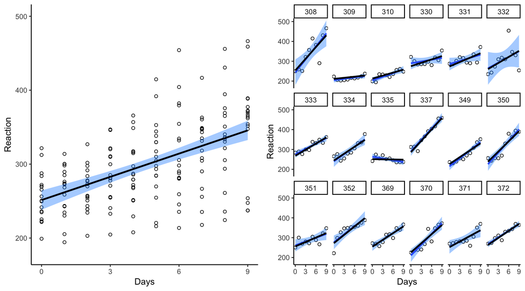

```r
newavg <- data.frame(Days = 0:9)
newavg$Reaction <- predict(pp_model_vivs, re.form = NA, newavg)
newvary <- expand.grid(Days = 0:9, Subject = unique(sleepstudy$Subject[1:nrow(sleepstudy)]))
newvary$Reaction <- predict(pp_model_vivs, newvary)

grid.arrange(
    p1 + geom_line(data = newavg, col = "black", size = 1),
    p2 + geom_line(data = newvary, col = "black", size = 1),
    ncol = 2)
```

The multilevel model with varying slopes and intercepts is giving very similar population-level and person-specific estimates (black lines) to what we saw with complete pooling and no pooling (blue lines and blue confidence bands). This is because the data are balanced and pretty uniformly non-noisy from person to person.

You might see that the black lines, relative to the blue lines, are very slightly shifted toward the group average. If the individual-level data were much noisier, this effect (‘shrinkage’) would be much more pronounced, reflecting our lack of trust in the individual-level data.

Next I will go back a step and fit a multilevel model that allows the intercept (average level of Reaction time) to vary from person to person, but assumes that everyone shows the same slope. That is, the degree of person-to-person variation in the way Reaction time changes over time is assumed to be exactly zero.

**Varying Intercept and No Slope Variability**

```r
pp_model_vi<-lmer(Reaction ~ 1+ Days + (1|Subject), data=sleepstudy)
round(coeftab(pp_model_vi, clevel=.95, sd=F, p.val=F),1)
```

```
##             Estimate  2.5% 97.5%
## (Intercept)    251.4 232.3 270.5
## Days            10.5   8.9  12.0
```

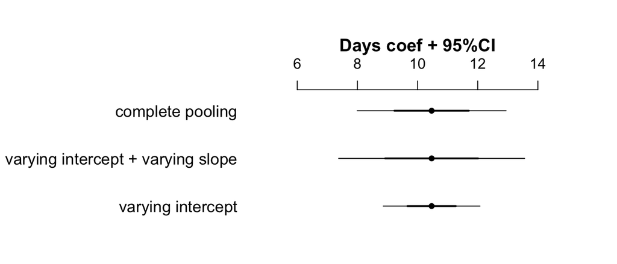

```r
#extract and then plot Days estimate from the different models
days_popcoefs<-c(coeftab(pp_model_vi,sd=T)[,1][2],coeftab(pp_model_vivs,sd=T)[,1][2],coeftab(cp_model,sd=T)[,1][2])
days_popses<-c(coeftab(pp_model_vi,sd=T)[,2][2],coeftab(pp_model_vivs,sd=T)[,2][2],coeftab(cp_model,sd=T)[,2][2])
names<-c("varying intercept", "varying intercept + varying slope", "complete pooling" )
coefplot2(days_popcoefs,days_popses, names, main="Days coef + 95%CI", xlim=c(5,15), cex.var=1.1)
```

Take a look at this varying-intercept model that assumes exactly zero slope variability. Relative to the complete pooling model, this model has widened the uncertainty interval around the population estimate of the intercept. However, the uncertainty interval around the population estimate of the Days slope is actually smaller than what we got with the complete pooling model. Meaning, this varying-intercept model is giving us an inappropriate degree of certainty in our estimate of the slope, relative to even the complete pooling model where we totally ignored that the data came from different subjects.

The interpretation of this is that, contingent on our assumption that people are identical in the way they change over time, we say that we are very certain about our estimate of this change. However, for this substantive topic this assumption is theoretically indefensible a priori and is clearly controverted by the data.

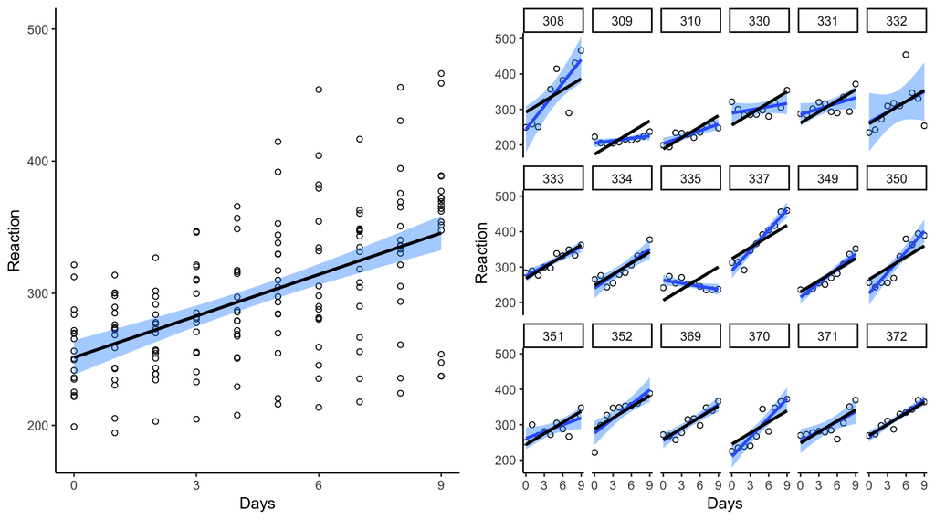

```r
newavg <- data.frame(Days = 0:9)
newavg$Reaction <- predict(pp_model_vi, re.form = NA, newavg)
newvary <- expand.grid(Days = 0:9, Subject = unique(sleepstudy$Subject[1:nrow(sleepstudy)]))
newvary$Reaction <- predict(pp_model_vi, newvary)

grid.arrange(
    p1 + geom_line(data = newavg, col = "black", size = 1),
    p2 + geom_line(data = newvary, col = "black", size = 1),
    ncol = 2)
```

Here’s a visualization of the varying intercept model, indicating that it is not an adequate description of the data at the individual subject level (subjects 308, 309, 335, 337, 350 and a few others are particularly poorly fit).

## Why am I not talking about “fixed” and “random” effects?

In a multilevel model, we are interested in the population distribution of some effect of interest (say, the effect of sleep deprivation). The model can estimate both the mean and variance of that distribution. One norm is to refer to the mean as the “fixed effect” and the variance as the “random effect”.

In terms of what’s going on under the hood, the “fixed” (mean) and “random” (variance) part of the distribution are estimated with a technique called *maximum likelihood*. These estimates can then be used to derive person-specific estimates, using a technique called *shrinkage*.

Typically, you estimate a “random effect” variance around a “fixed effect” mean if you are interested in generalizing to a population (e.g., how sleep deprivation affects people people in general) that your specific realizations (e.g., how sleep deprivation affected the specific the people in your study) were drawn from.

*Why you might want to avoid these terms:* The technical stuff and the “typically, you do this when you care about” don’t necessarily overlap. For one, it can be useful to estimate a “random” variance and use shrinkage even when you are not interested in a larger population. Also, there are many different ways these terms are used that are at times flatly contradictory. For example, “fixed effect model” and “random effects model” in fMRI is a particularly curious/idiosyncratic usage. Finally, usage of these terms is often not informative as to what what the varying effect structure actually was (i.e., did slopes vary or just intercepts?)

see: http://www.andrewgelman.com/2005/01/25/why_i_dont_use/

## SOME TAKE HOME POINTS

Multilevel modelling is an extension of basic regression.

It works as a default method for most of our research.

Don’t stop at the varying-intercept model, which is unrealistic and exaggerates the certainty in the effects we care about.

Make a lot of graphs, don’t rely on p-values or regression tables.

Think about effects within uncertainty bounds, visualize person to person differences.

Forget “fixed” and “random”, talk about what is allowed to vary and what is assumed to be exactly zero.

## USEFUL REFERENCES

good intro: Bolger & Laurenceau 2012 textbook http://www.intensivelongitudinal.com/

more advanced: Gelman & Hill 2007 textbook http://www.stat.columbia.edu/~gelman/arm/

## A FEW LOOSE ENDS / THINGS TO DEAL WITH IN THE FUTURE

*I used lmer, what are my degrees of freedom and p values?*

No one knows, which is why it isn’t given by default. You can use lmerTest to get Satterthwaite (fast, default) or Kenward-Rogers (slower, more accurate, not default) approximations. Typically these will give similar answers, and will also be similar to (but more conservative than) a z-test or asking if the 95%CI excludes zero.

*I added a varying slope and my p-value went up!*

This always happens. The model that assumes zero slope variance systematically underestimates the standard error associated with the overall effect (i.e., systematically makes your p value too small).

If the assumption of exactly zero slope variance was close to accurate, the p value will only go up a little bit.

If the assumption of exactly zero slope variance was really inaccurate, the p value can go way up. Meaning that once you account for person-to-person variability in the effect of x, the evidence that the overall effect is different from zero isn’t as strong.

There are examples in the literature of papers being retracted because they used fixed slope models but people reanalyzed them with varying slope models and got nonsignificant results

*What if there is more than one predictor variable?*

start with a varying intercept model

```r
#lmer(y ~ 1 + x1 + x2 + x1:x2, + (1|pID)
```

add varying slopes for the predictors

```r
#lmer(y ~ 1 + x1 + x2 + x1:x2 + (1+ x1 + x2 + x1:x2|pID)
```

you may run into problems with convergence

*What if my model doesn’t converge?*

this is probably a sign there is not enough information in your dataset to estimate these slope variances with much certainty

1. one option is to change the optimizer (see guide here: https://rstudio-pubs-static.s3.amazonaws.com/33653_57fc7b8e5d484c909b615d8633c01d51.html)

```r
#m1_changedoptimizer<-lmer(y ~ 1 + x1 + x2 + x1:x2 + (1 + x1 + x2 + x1:x2|pID), control=lmerControl(optimizer="bobyqa",ptCtrl=list(maxfun=2e5)))
```

2. another option would be to revert, because it is convenient, to a simpler model that assumes exactly zero person-to-person variability on some variables (see Bates et al. here: https://arxiv.org/abs/1506.04967)

```r
#m_maximalvaryingeffects<-lmer(y ~ 1 + x1 + x2 + x1:x2  + (1 + x1 + x2 + x1:x2|pID)

#m_reduced1<-lmer(y ~ 1 + x1 + x2 + x1:x2  + (1+ x1 + x2|pID)

#m_reduced2<-lmer(y ~ 1 + x1 + x2 + x1:x2  + (1 + x1|pID)

#m_reduced3<-lmer(y ~ 1 + x1 + x2 + x1:x2  + (1|pID)
```

3. a third option is to switch to bayesian estimation. this will always converge (it just might take a long time and/or require that you incorporate external information). in the past, this was technically demanding but there are now easy to use r packages. more importantly, this entails a change in statistical philosophy. the brms package on CRAN gives access to a wide variety of bayesian models with an lmer-like syntax.

```r
#b1<-brm(y ~ 1 + x1 + x2 + x1:x2  + (1 + x1 + x2 + x1:x2|pID), prior=NULL, cores=4, iter=500)
```

*Simpson’s paradox (aka ‘ecological fallacy’)*

one of the most useful features of multilevel models is that they can be used to look at between-person and within-person effects separately.

I had data once where people were writing a few sentences about negative autobiographical memories. I found that people who wrote longer texts (on average) tended to feel less negative about their memories (on average), but memories that elicited the writing of longer texts tended to be rated as more negative. Basically, there is no reason why the between-person effect of x on y should be the same as the within-person effect of x on y. The general term for this is “simpson’s paradox”.

See here: http://rstudio-pubs-static.s3.amazonaws.com/155188_cc8b400f7d134a3e9de6cbfb8320e1e0.html

*Person means and person-centered scores*

This interest in between-person versus within-person effects motivates decomposing variables into their between-person components (i.e., “person means”) and their within-person components (i.e., “person-centered” scores, which are deflections from the person mean). In cases (like my negative memory example) where the between- and within-person effects are truly different, this can really help to unpack what is going on.

```r
#some code illustrating how to do this and visualizing the results will go here
```

*What about allowing model intercepts or slopes to vary by stimulus (e.g., message/ad/video, etc.)?*

As a psychology researcher who cares about generalizing to a population of people beyond the people that happened to walk into my study, I care a lot about the varying slopes for different people.

Similarly, as communication researchers, we may care very much about generalizing to a population of messages beyond those that we happened to include in our study, so it can make sense to allow intercepts and slopes to vary by stimulus.

```r
#some code illustrating how to do this and visualizing the results will go here

#lmer(y ~ 1 + x1 + x2 + x1:x2  + (1 + x1|pID)  + (1|stimID)
```